# Final Project

AwesomePie1453

2023-11-13

# It’s the Final Project

### duh nuh nuh, duh duh duh duh duh, duh duh duh, duh duh duh duh duh duhuhh

I hope you enjoy my rendition of the Final Countdown up above. Go Europe, am I right?

Alright, so this project will be me expanding my horizons in R Markdown using statistics, which I previously haven’t done in R. I am attempting to make a project through R and knit it through github so you can just access it via the link. There will be multiple files here to access.

## Parlays

This project is designed to look at those who bet parlays in a larger sample and see what sets them apart. This is the exploratory analyses for my larger paper to be written this winter. I was not able to finish all the analyses due to time, but it gives me a good starting point, so I appreciate it!

### Read in the data

This is from our longitudinal study, wave 4, where the majority of these analyses will be conducted. I am taking our massive dataset and just selecting the wave 4 variables.

```r
library(haven)
library(dplyr)
library(tidyverse)
library(Hmisc)
```

```r
library(ggplot2)
Data <- read_sav("BGSU0007_merged_w5_OUTPUT copy.sav")
Wave_4 <- as_tibble(Data) %>%
  select(caseid_w5, starts_with("W5_"))
```

Alright, so we asked participants what types of sports bets they have made. The variable of interest here is a parlay, which is taking multiple bets and putting them together for a bigger payout. So let’s see how many people endorsed betting parlays!

```r
table(Wave_4$"W5_Q146_2")
```

```
##
##   1   2
## 206 191
```

Okay, so in this case, 1 = endorsed, 2 = did not endorse. That is the case for the majority of my binary variables. So 206 people bet parlays in this sample. Not bad.

Now, in this dataset I have a bunch of new variables looking at parlays specifically. I want to know what their frequencies are as well.

```r
Wave_4 %>%
  summarise(ParlayYes=sum(W5_Q146_2 ==1, na.rm=TRUE),
           ParlayNo=sum(W5_Q146_2 ==2, na.rm=TRUE),
           N = ParlayYes + ParlayNo,
           Parlay_Percent = ParlayYes / N,
           WinMoney = sum(W5_Q189_1 ==1, na.rm=TRUE),
           WinMoneyNo=sum(W5_Q189_1 ==2, na.rm=TRUE),
           WinMoney_Percent = WinMoney / ParlayYes,
          Fun = sum(W5_Q189_2 ==1, na.rm=TRUE),
           FunNo=sum(W5_Q189_2 ==2, na.rm=TRUE),
           Fun_Percent = Fun / ParlayYes,
          Action = sum(W5_Q189_3 ==1, na.rm=TRUE),
           ActionNo=sum(W5_Q189_3 ==2, na.rm=TRUE),
           Action_Percent = Action / ParlayYes,
          Payout = sum(W5_Q189_4 ==1, na.rm=TRUE),
           PayoutNo=sum(W5_Q189_4 ==2, na.rm=TRUE),
           Payout_Percent = Payout / ParlayYes,
          Boosted = sum(W5_Q189_5 ==1, na.rm=TRUE),
           BoostedNo=sum(W5_Q189_5 ==2, na.rm=TRUE),
           Boosted_Percent = Boosted / ParlayYes,
          Other = sum(W5_Q189_6 ==1, na.rm=TRUE),
           OtherNo=sum(W5_Q189_6 ==2, na.rm=TRUE),
           Other_Percent = Other / ParlayYes,
          Neg200 = sum(W5_Q190 ==1, na.rm=TRUE),
          Neg200_Percent = Neg200 / ParlayYes,
          Even_200 = sum(W5_Q190 ==2, na.rm=TRUE),
          Even_200_Percent = Even_200 / ParlayYes,
          F100_200 = sum(W5_Q190 ==3, na.rm=TRUE),
          F100_200_Percent = F100_200 / ParlayYes,
          F200_500 = sum(W5_Q190 ==4, na.rm=TRUE),
          F200_500_Percent = F200_500 / ParlayYes,
          F500_1000 = sum(W5_Q190 ==5, na.rm=TRUE),
          F500_1000_Percent = F500_1000 / ParlayYes,
          F1K_2K = sum(W5_Q190 ==6, na.rm=TRUE),
          F1K_2K_Percent = F1K_2K / ParlayYes,
          F2K_5K = sum(W5_Q190 ==7, na.rm=TRUE),
          F2K_5K_Percent = F2K_5K / ParlayYes,
          F5K_10K = sum(W5_Q190 ==8, na.rm=TRUE),
          F5K_10K_Percent = F5K_10K / ParlayYes,
          F10K = sum(W5_Q190 ==9, na.rm=TRUE),
          F10K_Percent = F10K / ParlayYes,
          FOther = sum(W5_Q190 ==10, na.rm=TRUE),
          FOther_Percent = FOther / ParlayYes,
          LoseLot = sum(W5_Q191 ==1, na.rm=TRUE),
          LoseLot_Percent = LoseLot / ParlayYes,
          LoseLittle = sum(W5_Q191 ==2, na.rm=TRUE),
          LoseLittle_Percent = LoseLittle / ParlayYes,
          BreakEven = sum(W5_Q191 ==3, na.rm=TRUE),
          BreakEven_Percent = BreakEven / ParlayYes,
          WinSome = sum(W5_Q191 ==4, na.rm=TRUE),
          WinSome_Percent = WinSome / ParlayYes,
          WinLot = sum(W5_Q191 ==5, na.rm=TRUE),
          WinLot_Percent = WinLot / ParlayYes
          )
```

```
## # A tibble: 1 × 52
##   ParlayYes ParlayNo     N Parlay_Percent WinMoney WinMoneyNo WinMoney_Percent
##       <int>    <int> <int>          <dbl>    <int>      <int>            <dbl>
## 1       206      191   397          0.519      171         35            0.830
## # … with 45 more variables: Fun <int>, FunNo <int>, Fun_Percent <dbl>,
## #   Action <int>, ActionNo <int>, Action_Percent <dbl>, Payout <int>,
## #   PayoutNo <int>, Payout_Percent <dbl>, Boosted <int>, BoostedNo <int>,
## #   Boosted_Percent <dbl>, Other <int>, OtherNo <int>, Other_Percent <dbl>,
## #   Neg200 <int>, Neg200_Percent <dbl>, Even_200 <int>, Even_200_Percent <dbl>,
## #   F100_200 <int>, F100_200_Percent <dbl>, F200_500 <int>,
## #   F200_500_Percent <dbl>, F500_1000 <int>, F500_1000_Percent <dbl>, …
```

Enjoy the massive table above. Let me write down some of the key parts here.

206 people (51.89%) of the sample endorsed betting parlays. Why did they bet parlays? 83% did it to win money, 71.8% because it was fun, 38.8% to have action on multiple games, 47.6% for the potential of a high payout, 33% due to boosted odds tokens.

As far as the odds they are typically betting, its fairly normal. I made these number brackets up arbitrarily for what I thought made sense. Let’s look at a frequency distribution of it

```r
dplyr::count(Wave_4, W5_Q190)
```

```
## # A tibble: 9 × 2
##   W5_Q190                     n
##   <dbl+lbl>               <int>
## 1  1 [-200 or lower]         16
## 2  2 [Even money to -200]    24
## 3  3 [+100 to +200]          35
## 4  4 [+200 to +500]          60
## 5  5 [+500 to +1000]         46
## 6  6 [+1000 to +2000]        13
## 7  7 [+2000 to +5000]         8
## 8 10 [Other]                  4
## 9 NA                       4157
```

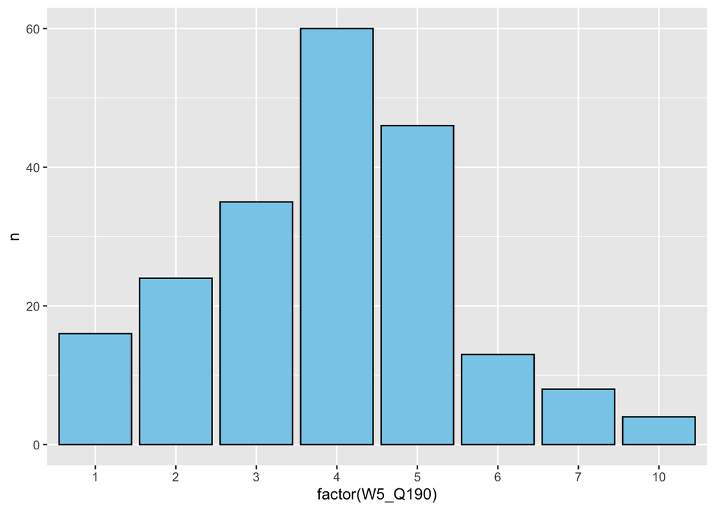

```r
Wave_4_Filtered <- filter(Wave_4, !is.na(W5_Q190))
count_lay <- count(Wave_4_Filtered, W5_Q190)
ggplot(count_lay, aes(x = factor(W5_Q190), y = n)) + geom_bar(stat = "identity", fill = "skyblue", color = "black")
```

I won’t go into detail on what these mean, but typically people are betting from even money (+100) to +1000 (10 to 1) parlays.

Next, I want to look at how much people are typically losing/making when betting parlays.

```r
dplyr::count(Wave_4, W5_Q191)
```

```
## # A tibble: 6 × 2
##   W5_Q191                                  n
##   <dbl+lbl>                            <int>
## 1  1 [I typically lose a lot of money]     5
## 2  2 [I typically lose some money]        73
## 3  3 [I typically break even]             63
## 4  4 [I typically win some money]         62
## 5  5 [I typically win a lot of money]      3
## 6 NA                                    4157
```

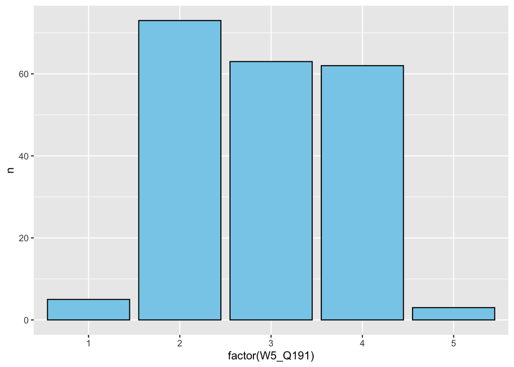

```r
count_lay <- count(Wave_4_Filtered, W5_Q191)
ggplot(count_lay, aes(x = factor(W5_Q191), y = n)) + geom_bar(stat = "identity", fill = "skyblue", color = "black")
```

So our sample is not claiming to win or lose a ton of money, but sit around average. More people are losing than winning (self-report) but nothing crazy.

Okay now that we know our variables, its time to do some T tests. Go to ttest.rmd to see it.

ListOfVariables.Rmd has the names of any variables if you are interested.